# Take home exercise

Take home exercise 01

Li Minqi https://www.linkedin.com/in/minqi-li/ (School of Computing and Information System)https://example.com/spacelysprokets  
2022-04-24

# Overview

In this take-home exercise, appropriate static statistical graphics methods are used to reveal the demographic of the city of Engagement, Ohio USA.

The data should be processed by using appropriate tidyverse family of packages and the statistical graphics must be prepared using ggphot2 and its extensions.

# Getting Started

Before we get started, it is important for us to ensure that the required R packages have been installed. If yes, we will load the R packages. If they have yet to be installed, we will install the R packages and load them onto R environment.

The chunk code below will do the trick.

```r
packages = c('tidyverse')

for(p in packages){
  if(!require(p,character.only= T)){
    install.packages(p)
  }
  library(p,character.only=T)
}
```

# Importing Data

The code chunk below import *Participants.csv* from the data folder into R by using [`read_csv()`](https://readr.tidyverse.org/reference/read_delim.html) of [**readr**](https://readr.tidyverse.org/) and save it as an tibble data frame called *participant_data*.

```r
participant_data <- read_csv("data/Participants.csv")
```

# A Simple Bar Chart

The code chunk below plot a bar chart by using geom_bar() of ggplot2. It shows that the number of people with kids is much lesser than the number of people without a kid. The fertility rate is low.

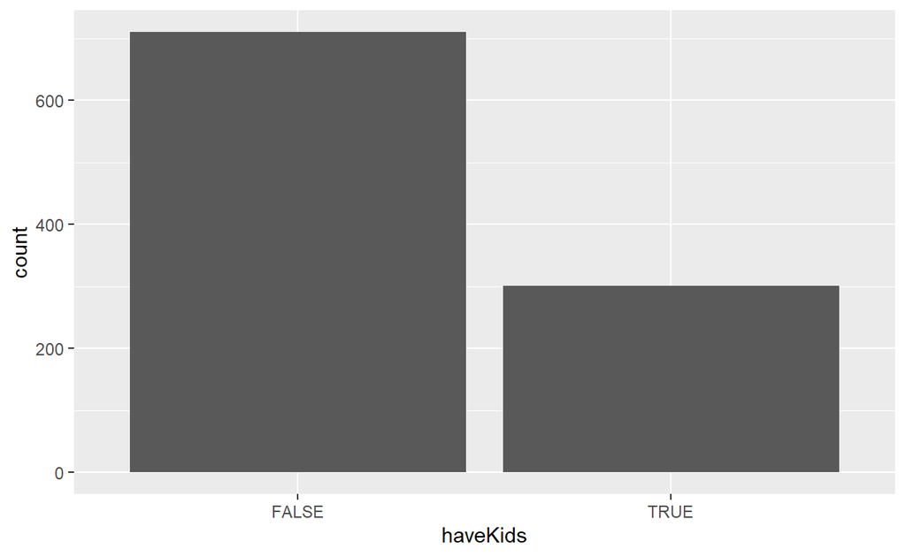

```r
ggplot(data=participant_data,
       aes(x = haveKids)) +
  geom_bar()
```

From the bar chart below, we can tell that people with higher education, will be less likely to have a child.

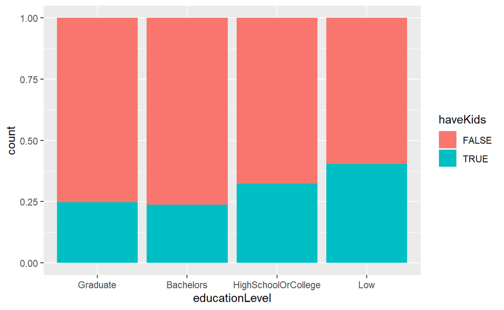

```r
participant_data$educationLevel <- factor(participant_data$educationLevel,levels = c("Graduate", "Bachelors", "HighSchoolOrCollege","Low"))
ggplot(data=participant_data,
aes(x=educationLevel,fill = haveKids)) +
geom_bar(position = "fill")
```

According to the bar chart below, within the sample, majority of the people have high school and college as their highest education level

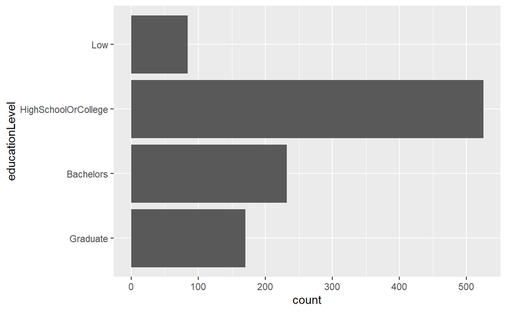

```r
ggplot(data=participant_data,
       aes(x = educationLevel)) +
  geom_bar() + coord_flip()
```

The code chunk below plot a bar chart by using geom_density() of ggplot2. People with higher education level will have higher chance to feel happy if they do not have kid(s). On the other hand, people with low education level will have higher chance to feel happy if they have kid(s).

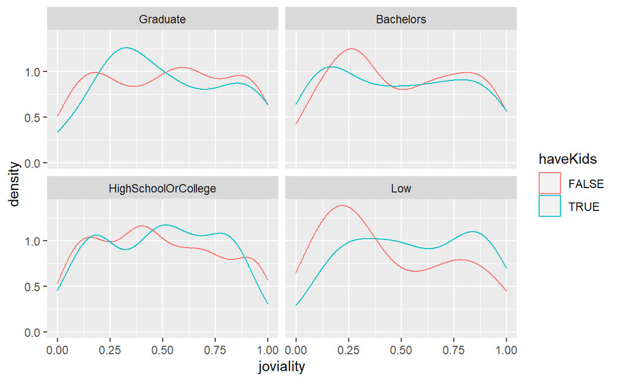

```r
ggplot(data=participant_data,
aes(x=joviality,colour = haveKids)) +
geom_density() +
facet_wrap(~ educationLevel)
```

People at the age in between of 50 to 60, feel less happier than people at other ages.

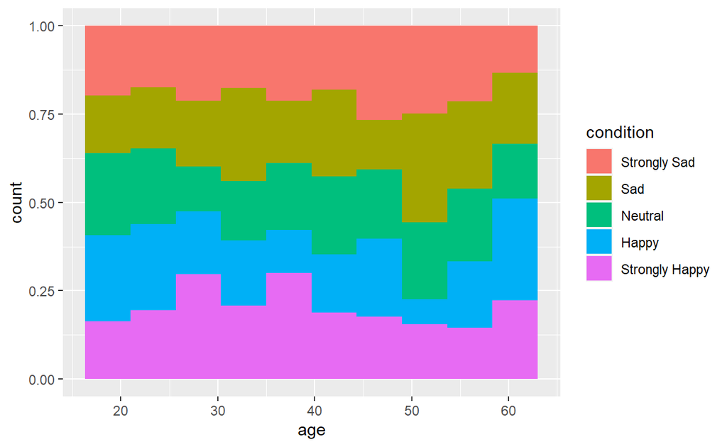

```r
condition<- cut(participant_data$joviality, breaks = c(0,0.2,0.4,0.6,0.8,1), labels = c("Strongly Sad","Sad","Neutral","Happy","Strongly Happy"))

ggplot(data=participant_data, aes(fill=condition, x=age)) +
    geom_histogram(position="fill", bins=10)
```